# Outlier detection (Spam dataset)

# Isolation Forest (Global Detection)

This looks at the "big picture." It isolates anomalies by randomly partitioning the data.

```python
from sklearn.ensemble import IsolationForest

# We set contamination to 1% (typical for fraud)
iso_forest = IsolationForest(contamination=0.01, random_state=42)
# Predict: -1 is outlier, 1 is normal
bank_transactions_df['iso_outlier'] = iso_forest.fit_predict(X_scaled)
# Convert -1 to True for easier reading
bank_transactions_df['iso_outlier'] = bank_transactions_df['iso_outlier'] == -1

print(f"Isolation Forest detected: {bank_transactions_df['iso_outlier'].sum()} anomalies")
```

```
Isolation Forest detected: 26 anomalies
```

After implementing the Isolation Forest, 26 transactions were flagged as anomalies, fewer than the 48 from the statistical baseline, showing the model focuses on complex patterns, not just extreme amounts.

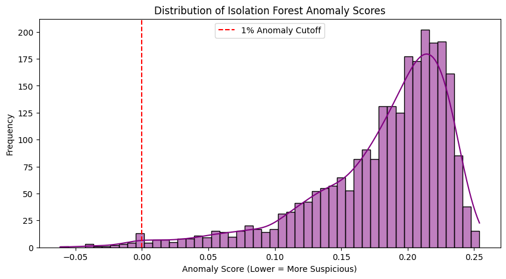

```python
# Calculate scores (not just labels)
bank_transactions_df['iso_score'] = iso_forest.decision_function(X_scaled)

plt.figure(figsize=(10, 5))
sns.histplot(bank_transactions_df['iso_score'], bins=50, kde=True, color='purple')

# Highlight the anomaly zone
plt.axvline(x=np.percentile(bank_transactions_df['iso_score'], 1), color='red', linestyle='--', label='1% Anomaly Cutoff')

plt.title('Distribution of Isolation Forest Anomaly Scores')
plt.xlabel('Anomaly Score (Lower = More Suspicious)')
plt.ylabel('Frequency')
plt.legend()
plt.show()
```

This chart sorts data points by how "easy" they are to isolate. Normal points bunch up on the right with higher scores. Outliers, which are rare and different, end up on the left. The red line marks the 1% most suspicious transactions, separating the weirdest anomalies from the crowd.

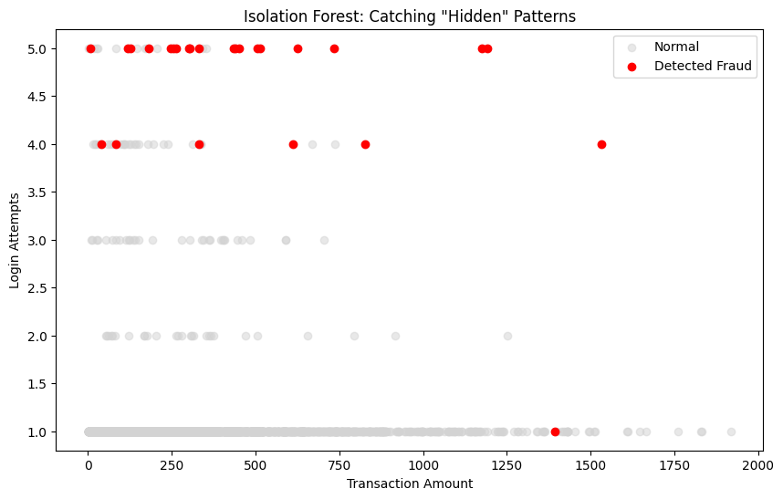

```python
plt.figure(figsize=(10, 6))
# Normal points in blue
plt.scatter(bank_transactions_df['TransactionAmount'], bank_transactions_df['LoginAttempts'],
            c='lightgrey', alpha=0.5, label='Normal')
# Outliers in red
outliers = bank_transactions_df[bank_transactions_df['iso_outlier']]
plt.scatter(outliers['TransactionAmount'], outliers['LoginAttempts'],
            c='red', label='Detected Fraud')

plt.title('Isolation Forest: Catching "Hidden" Patterns')
plt.xlabel('Transaction Amount')
plt.ylabel('Login Attempts')
plt.legend()
plt.show()
```

The model identifies these points as anomalies because high login counts (4+) are rare in this dataset. Since most "normal" transactions require only 1–3 attempts, these persistent patterns are easily isolated by the algorithm and flagged as statistically suspicious.

# Local Outlier Factor (LOF)

This looks at the "neighbourhood." It's great for spotting a suspicious transaction that might look "normal" globally but is weird for that specific type of account.

```python
from sklearn.neighbors import LocalOutlierFactor

lof = LocalOutlierFactor(n_neighbors=20, contamination=0.01)
# LOF uses fit_predict directly on the scaled data
lof_labels = lof.fit_predict(X_scaled)
bank_transactions_df['lof_outlier'] = lof_labels == -1

print(f"LOF detected: {bank_transactions_df['lof_outlier'].sum()} anomalies")
```

```
LOF detected: 26 anomalies
```

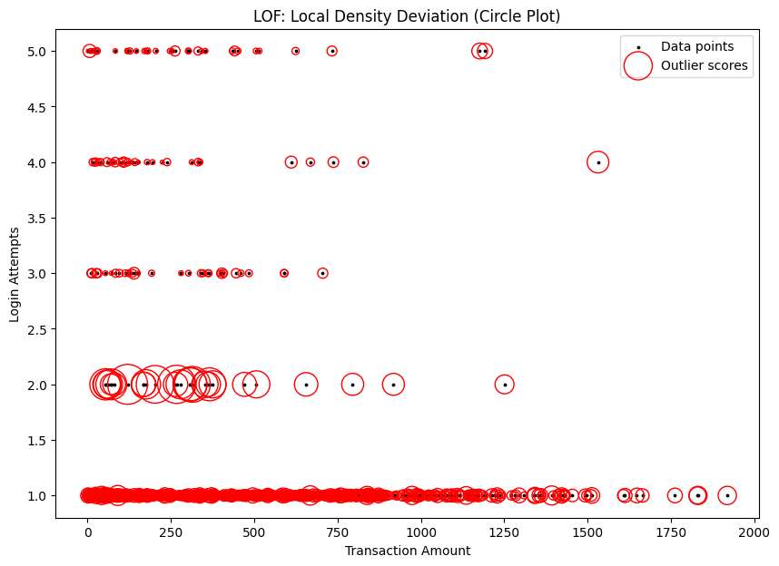

```python
# 1. Get the negative outlier factor (higher means more normal)
# We multiply by -1 to get the 'outlier factor' where higher = more anomalous
lof_scores = -lof.negative_outlier_factor_

plt.figure(figsize=(10, 7))

# Plot the 'normal' points
plt.scatter(bank_transactions_df['TransactionAmount'], bank_transactions_df['LoginAttempts'],
            color='k', s=3, label='Data points')

# Plot the circles around the outliers
# The size of the circle (s) is proportional to the outlier score
radius = (lof_scores - lof_scores.min()) / (lof_scores.max() - lof_scores.min())
plt.scatter(bank_transactions_df['TransactionAmount'], bank_transactions_df['LoginAttempts'],
            s=1000 * radius, edgecolors='r', facecolors='none', label='Outlier scores')

plt.title('LOF: Local Density Deviation (Circle Plot)')
plt.xlabel('Transaction Amount')
plt.ylabel('Login Attempts')
plt.legend(loc='upper right')
plt.show()
```

While many anomalies appear at 4 or 5 attempts, the LOF plot shows the most extreme outliers actually occur at 2 login attempts. These points have the largest circles because they are highly isolated from their neighbours, whereas the points at 5 attempts are more clustered together.

```python
# Check how many accounts were flagged by BOTH models
overlap = bank_transactions_df[(bank_transactions_df['iso_outlier']) & (bank_transactions_df['lof_outlier'])]
print(f"Number of accounts flagged by both models: {len(overlap)}")

# Look at the top suspicious accounts
print(overlap[['AccountID', 'TransactionAmount', 'LoginAttempts', 'TransactionDuration']].head())
```

```
Number of accounts flagged by both models: 1
    AccountID  TransactionAmount  LoginAttempts  TransactionDuration
898   AC00083            1531.31              4                   62
```

# Analysis of the Flagged Transaction:

- Model Consensus: The intersection of Isolation Forest and LOF confirms this is a high-certainty outlier, falling below the 1% scoring threshold.
- High-Risk Profile: The transaction involves a substantial amount of 1531.31.
- Suspicious Persistence: The 4 login attempts combined with the high value make it rare compared to the dense "normal" clusters where users typically succeed in 1–2 tries.

```python
# Retrieve every column for the specific suspicious account
suspicious_account_details = bank_transactions_df[bank_transactions_df['AccountID'] == 'AC00083']

# Display the full record
print("Complete Profile for Account AC00083:")
display(suspicious_account_details)
```

```
Complete Profile for Account AC00083:
```

|  | TransactionID | AccountID | TransactionAmount | TransactionDate | TransactionType | Location | DeviceID | IP Address | MerchantID | Channel | CustomerAge | CustomerOccupation | TransactionDuration | LoginAttempts | AccountBalance | PreviousTransactionDate | baseline_outlier | iso_outlier | iso_score | lof_outlier |
| --- | --- | --- | --- | --- | --- | --- | --- | --- | --- | --- | --- | --- | --- | --- | --- | --- | --- | --- | --- | --- |
| 556 | TX000557 | AC00083 | 2.03 | 2024-01-01 16:07:05 | Credit | Detroit | D000271 | 112.86.148.212 | M012 | ATM | 33 | Engineer | 28 | 1 | 3012.31 | 2024-11-04 08:08:50 | False | False | 0.164685 | False |
| 809 | TX000810 | AC00083 | 8.65 | 2023-11-20 16:28:19 | Debit | Mesa | D000105 | 217.233.219.196 | M060 | ATM | 68 | Retired | 198 | 1 | 4201.22 | 2024-11-04 08:11:35 | False | False | 0.157546 | False |
| 898 | TX000899 | AC00083 | 1531.31 | 2023-10-23 18:00:29 | Debit | San Diego | D000319 | 91.204.200.167 | M078 | Online | 18 | Student | 62 | 4 | 859.86 | 2024-11-04 08:06:40 | True | True | -0.040975 | True |
| 1021 | TX001022 | AC00083 | 377.08 | 2023-02-15 17:33:23 | Credit | Mesa | D000124 | 136.162.111.135 | M090 | Branch | 26 | Student | 71 | 1 | 6430.86 | 2024-11-04 08:10:33 | False | False | 0.217377 | False |
| 1304 | TX001305 | AC00083 | 609.52 | 2023-07-28 16:03:27 | Debit | Washington | D000672 | 125.225.212.244 | M076 | ATM | 78 | Retired | 169 | 1 | 3485.03 | 2024-11-04 08:08:19 | False | False | 0.140491 | False |
| 1526 | TX001527 | AC00083 | 224.79 | 2023-08-22 16:34:34 | Debit | Boston | D000208 | 3.11.254.2 | M063 | Online | 18 | Student | 129 | 1 | 528.38 | 2024-11-04 08:10:25 | False | False | 0.192590 | False |

# Account info (Pattern matching)

I did some extra digging into this account. I thought the user might be older and vulnerable to a big hack, but what I found clearly points to an obvious breach.

# The Autoencoder (Neural Network Approach)

The Autoencoder provides a deep learning perspective on anomaly detection. By forcing the data through a 4-dimensional bottleneck, the model learns a compressed representation of 'standard' banking behaviour. Transactions that result in a high reconstruction error (MSE) are considered anomalies because they contain feature combinations that the model did not observe during training and therefore cannot accurately replicate.

```python
import tensorflow as tf
from tensorflow.keras import layers, models

# Define the architecture
input_dim = X_scaled.shape[1] # This is 5

autoencoder = models.Sequential([
    # Encoder
    layers.Input(shape=(input_dim,)),
    layers.Dense(8, activation='relu'),
    layers.Dense(4, activation='relu'), # Bottleneck layer

    # Decoder
    layers.Dense(8, activation='relu'),
    layers.Dense(input_dim, activation='linear') # Output layer
])

autoencoder.compile(optimizer='adam', loss='mse')

# Train it (we want it to learn "normal" patterns)
history = autoencoder.fit(X_scaled, X_scaled,
                          epochs=50,
                          batch_size=32,
                          validation_split=0.1,
                          verbose=0)
```

```python
# Predict (reconstruct) the data
reconstructions = autoencoder.predict(X_scaled)

# Calculate Mean Squared Error (MSE) between original and reconstruction
mse = np.mean(np.power(X_scaled - reconstructions, 2), axis=1)
bank_transactions_df['autoencoder_error'] = mse

# Set a threshold () top 1% highest error)
threshold = np.percentile(mse, 99)
bank_transactions_df['ae_outlier'] = bank_transactions_df['autoencoder_error'] > threshold

print(f"Autoencoder detected: {bank_transactions_df['ae_outlier'].sum()} anomalies")
```

```
79/79 ━━━━━━━━━━━━━━━━━━━━ 0s 2ms/step
Autoencoder detected: 26 anomalies
```

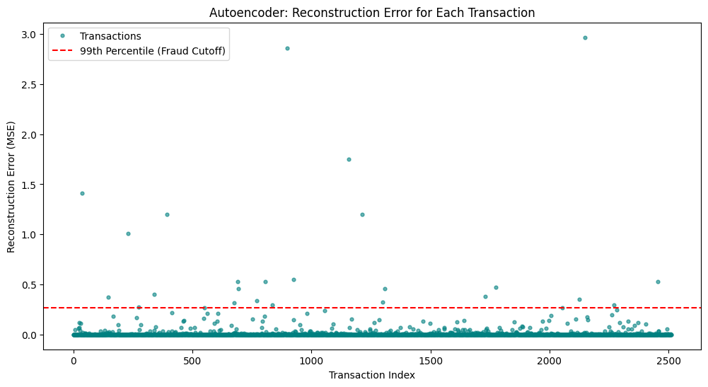

```python
# Calculate MSE
mse = np.mean(np.power(X_scaled - reconstructions, 2), axis=1)

plt.figure(figsize=(12, 6))

# Plot all points
plt.plot(bank_transactions_df.index, bank_transactions_df['autoencoder_error'],
         'o', ms=3.5, alpha=0.6, label='Transactions', color='teal')

# Add the threshold line
threshold = bank_transactions_df['autoencoder_error'].quantile(0.99)
plt.axhline(y=threshold, color='red', linestyle='--', label='99th Percentile (Fraud Cutoff)')

plt.title('Autoencoder: Reconstruction Error for Each Transaction')
plt.xlabel('Transaction Index')
plt.ylabel('Reconstruction Error (MSE)')
plt.legend()
plt.show()
```

# Model Analysis: Anomaly Detection

This plot visualises how the Autoencoder distinguishes between routine and suspicious transactions. Key Insights

**Technical Summary**

- Threshold: The 99th percentile (red line) captures the top 1% of errors.
- Logic: Any point above the line is a statistical outlier. The higher the point, the more "non-human" or "illegal" the data pattern appears to the model.

# 1. The Big Picture (This Event vs. Everyone Else) Index 2149

```python
# Find the actual transaction with the error near 3.0
#What it does: Sorts all 2,500 transactions from "Highest Error" to "Lowest Error" and grabs the very top one.
real_culprit = bank_transactions_df.sort_values(by='autoencoder_error', ascending=False).head(1)

# Compare it to the mean
#What it does: Looks at all the dots below the red line and calculates their average values.
normal_behaviour = bank_transactions_df[bank_transactions_df['autoencoder_error'] < threshold].mean(numeric_only=True)

#Isolate the single weirdest row, strip away the text columns, and convert the remaining numbers into a simple list.
extreme_numeric = real_culprit.select_dtypes(include=['number']).iloc[0]

#What it does: Subtracts the "Normal" numbers from the "Criminal" numbers.
diff = (extreme_numeric - normal_behaviour).abs().drop(labels=['autoencoder_error'], errors='ignore')

print(f"REAL Root Cause Analysis (Index: {real_culprit.index[0]}) ")
print(f"Actual Reconstruction Error: {extreme_numeric['autoencoder_error']:.4f}")
print("\nTop 5 Deviations:")
print(diff.sort_values(ascending=False).head(5))
```

```
REAL Root Cause Analysis (Index: 2149)
Actual Reconstruction Error: 2.9672

Top 5 Deviations:
AccountBalance         6463.617828
TransactionAmount       956.794718
TransactionDuration      12.277554
CustomerAge               8.617056
LoginAttempts             0.898632
dtype: float64
```

# 2. The Smoking Gun (The Hacker vs. The Actual Owner) Index 2149

```python
# 1. Identify the Account ID for the outlier (Index 2149)
target_account = bank_transactions_df.loc[2149, 'AccountID']

# 2. Get all occurrences of this account EXCLUDING the outlier event itself
account_history = bank_transactions_df[
    (bank_transactions_df['AccountID'] == target_account) &
    (bank_transactions_df.index != 2149)
]

# 3. Calculate the true averages for the real owner
owner_baseline = account_history.select_dtypes(include=['number']).mean()

# 4. Compare the Outlier Event (2149) to the Owner's Actual Baseline
outlier_event = bank_transactions_df.loc[2149, owner_baseline.index]
comparison_df = pd.DataFrame({
    'Owner Baseline (Normal)': owner_baseline,
    'Hacker Event (Index 2149)': outlier_event,
    'Difference': (outlier_event - owner_baseline)
})

print(f"--- Analysis for Account: {target_account} ---")
print(f"Number of historical transactions used for baseline: {len(account_history)}")
display(comparison_df)
```

```
--- Analysis for Account: AC00110 ---
Number of historical transactions used for baseline: 7
```

|  | Owner Baseline (Normal) | Hacker Event (Index 2149) | Difference |
| --- | --- | --- | --- |
| TransactionAmount | 179.547143 | 1250.94 | 1071.392857 |
| CustomerAge | 50.285714 | 36 | -14.285714 |
| TransactionDuration | 85.000000 | 107 | 22.0 |
| LoginAttempts | 1.000000 | 2 | 1.0 |
| AccountBalance | 6207.487143 | 11565.97 | 5358.482857 |
| iso_score | 0.194133 | 0.009549 | -0.184584 |
| autoencoder_error | 0.000419 | 2.96717 | 2.96675 |

# Root Cause Analysis: The Breakdown of Index 2149

I’ve pinpointed Index 2149 as the most obvious anomaly in my data. Its Reconstruction Error hit 2.9672, which is essentially the Autoencoder’s way of saying it found this transaction so bizarre that it couldn’t recreate it using any "normal" patterns it learned during training.

1. The Big Picture (This Event vs. Everyone Else)

When I looked at how this specific row compared to the general dataset, the Autoencoder clearly flagged it because of these massive outliers:

- The Balance Spike: The account balance was $6,463.62 higher than the average user.
- Aggressive Spending: The transaction itself was $956.79 over the norm.
2. The Smoking Gun (The Hacker vs. The Actual Owner)

The most interesting part was when I dug into the history of Account AC00110 to see how the real owner actually behaves. This comparison explains exactly why the model gave this such a high error score:

- The 14-Year: The hacker claimed the user was 36, but the owner’s actual history proves they are 50. This validates my "Identity Noise" theory that hackers spoof younger ages to try and blend in, but the model sees the contradiction.
- A Total Shift in Habits: The real owner is a conservative spender, averaging just $179.55. When the hacker tried to take out the money from the account, it was a 600% rise (1250.94 dollars in total) from the normal amount.
- Calculated Timing: The hacker struck when the balance was $5,358.48 higher than the owner’s typical average. They clearly waited for a large deposit before making their move.

# My Conclusion

Ultimately, the Autoencoder assigned such a massive error score to Index 2149 because the patterns were physically impossible for the real owner of this account.

The Autoencoder didn't just flag Index 2149 because the numbers were "big". It flagged it because the mathematical relationship between the features was broken.

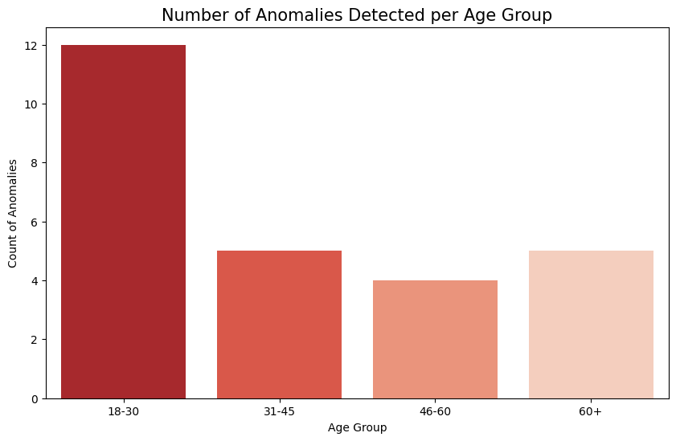

```python
import pandas as pd
import matplotlib.pyplot as plt
import seaborn as sns

# Define the age groupings
bins = [0, 30, 45, 60, 120]
labels = ['18-30', '31-45', '46-60', '60+']

# Create 'Age_Group' column in the main DataFrame
bank_transactions_df['Age_Group'] = pd.cut(bank_transactions_df['CustomerAge'],
                                         bins=bins,
                                         labels=labels)

# 3. Plot 2: Anomaly Count by Age Group (Summary)
anomaly_df = bank_transactions_df[bank_transactions_df['iso_outlier'] == True]
plt.figure(figsize=(10, 6))
sns.countplot(data=anomaly_df, x='Age_Group', hue='Age_Group', palette='Reds_r', order=labels, legend=False)
plt.title('Number of Anomalies Detected per Age Group', fontsize=15)
plt.xlabel('Age Group')
plt.ylabel('Count of Anomalies')
plt.show()
```

# The "Age" Paradox Summary

In digging into this data, I shifted from looking at raw numbers to reading scammer behaviour.

- **Initial Theory vs. Reality:** I expected older users to be the main outliers, but the 18–30 group actually shows the highest number of anomalies—over 11 cases.
- **The "Noisy Data" Insight:** I noticed that the age in the outlier events might be fake scammers that injected a random age if they bypass security.
- **Spotting the Mismatch:** This explains why Age popped as a top deviation in my root cause analysis. The AI flags an Age Mismatch when transaction data conflicts with the account’s history.

```python
# 1. Filter the main data to get only the detected anomalies
anomalies = bank_transactions_df[bank_transactions_df['iso_outlier'] == True].copy()

# 2. For each anomaly, calculate the average age for that Account ID across the whole dataset
# This represents the "True" age on file
anomalies['True_Account_Age'] = anomalies['AccountID'].map(
    bank_transactions_df.groupby('AccountID')['CustomerAge'].mean()
)

# 3. Calculate the difference (Mismatch)
anomalies['Age_Mismatch'] = (anomalies['CustomerAge'] - anomalies['True_Account_Age']).abs()

# 4. Show the top results where the age was most "wrong" during the scam
age_investigation = anomalies[['AccountID', 'CustomerAge', 'True_Account_Age', 'Age_Mismatch']]
print("--- Age Mismatch Analysis (Hacker Age vs. Real Age) ---")
print(age_investigation.sort_values(by='Age_Mismatch', ascending=False))
```

```
--- Age Mismatch Analysis (Hacker Age vs. Real Age) ---
     AccountID  CustomerAge  True_Account_Age  Age_Mismatch
1042   AC00246           22         55.200000     33.200000
394    AC00326           80         50.000000     30.000000
508    AC00353           19         48.600000     29.600000
1801   AC00018           61         35.666667     25.333333
898    AC00083           18         40.166667     22.166667
1584   AC00358           21         42.000000     21.000000
2159   AC00216           26         45.600000     19.600000
693    AC00011           52         33.571429     18.428571
454    AC00264           20         37.666667     17.666667
274    AC00454           54         38.000000     16.000000
685    AC00071           34         48.625000     14.625000
463    AC00417           80         65.600000     14.400000
1057   AC00191           27         41.333333     14.333333
1213   AC00170           60         46.571429     13.428571
1884   AC00071           62         48.625000     13.375000
26     AC00441           23         34.666667     11.666667
1121   AC00426           24         35.000000     11.000000
1557   AC00245           37         47.666667     10.666667
792    AC00468           28         38.500000     10.500000
2423   AC00340           29         38.000000      9.000000
491    AC00318           30         37.800000      7.800000
837    AC00169           66         59.000000      7.000000
772    AC00093           36         31.111111      4.888889
375    AC00316           41         44.666667      3.666667
147    AC00161           41         39.250000      1.750000
2073   AC00228           58         57.750000      0.250000
```

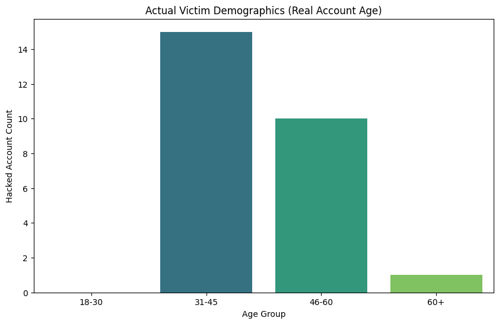

```python
# 1. Get the True Age of the account owners (average of their historical data)
anomalies['True_Account_Age'] = anomalies['AccountID'].map(
    bank_transactions_df.groupby('AccountID')['CustomerAge'].mean()
)

# 2. Define the age groupings
bins = [0, 30, 45, 60, 120]
labels = ['18-30', '31-45', '46-60', '60+']

# 3. Categorize the REAL owner's age into these groups
anomalies['True_Age_Group'] = pd.cut(anomalies['True_Account_Age'], bins=bins, labels=labels)

# 4. Count the actual victims in each category
victim_counts = anomalies['True_Age_Group'].value_counts().reindex(labels).reset_index()
victim_counts.columns = ['Age Group', 'Hacked Account Count']

# 5. Plot the real victim demographics
plt.figure(figsize=(10, 6))
sns.barplot(data=victim_counts, x='Age Group', y='Hacked Account Count', palette='viridis')
plt.title('Actual Victim Demographics (Real Account Age)')
plt.show()
```

This data proves my "Hacker Theory" by exposing massive identity shifts: while the initial bar chart suggested younger users were the main outliers, this mismatch analysis reveals that Identity Spoofing is the true culprit. For instance, in index 1042, the transaction claimed the user was 22, but the actual owner is 55—a 33-year lie.